# R Notebook Lesson 1:Creating and Using R Notebooks

```r
setwd("~/GIT/2020.05.15_Rnotebook_learning")
```

This R notebook provides a breif introduction to R notebooks.

The next below is total filler text. Lorem ipsum dolor sit amet, consectetur adipiscing elit, sed do eiusmod tempor incididunt ut labore et dolore magna aliqua. Ut enim ad minim veniam, quis nostrud exercitation ullamco laboris nisi ut aliquip ex ea commodo consequat. Duis aute irure dolor in reprehenderit in voluptate velit esse cillum dolore eu fugiat nulla pariatur. Excepteur sint occaecat cupidatat non proident, sunt in culpa qui officia deserunt mollit anim id est laborum.

I learned where shell was when github thought I was two different people. Navigate to the tools and scroll to shell under “Tools”.

# Sections

The next section will go over sections and subsections

## (Bit smaller) Subsections

Ut enim ad minim veniam, quis nostrud exercitation ullamco laboris nisi ut aliquip ex ea commodo consequat.

### (even smaller) Sections and sub-Subsections

Duis aute irure dolor in reprehenderit in voluptate velit esse cillum dolore eu fugiat nulla pariatur.

#### What will this produce?

Excepteur sint occaecat cupidatat non proident, sunt in culpa qui officia deserunt mollit anim id est laborum.

##### How about now

Excepteur sint occaecat cupidatat non proident, sunt in culpa qui officia deserunt mollit anim id est laborum.

###### can you even read this?

Excepteur sint occaecat cupidatat non proident, sunt in culpa qui officia deserunt mollit anim id est laborum.

## Tell R that you want to write in {R}

after typing three ` (i.e. ```) there use brackets to specify the language that you are using

# Histogram Time!

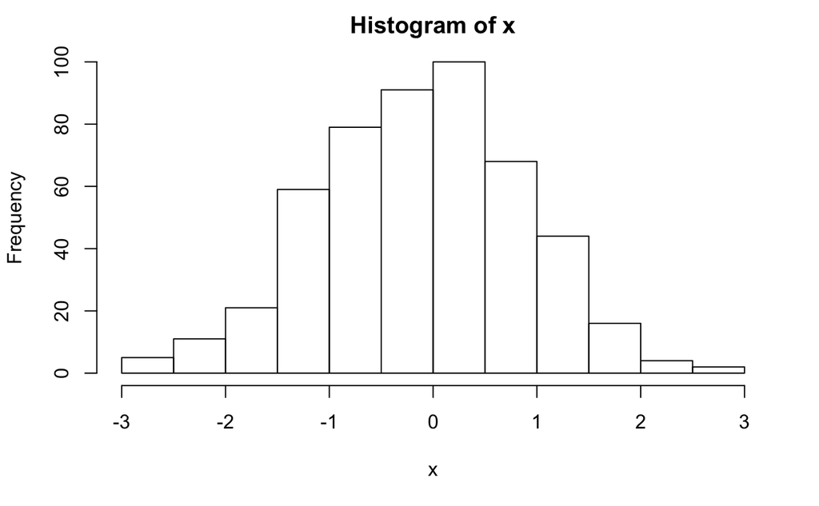

```r
x <- rnorm(500)
hist(x)
```

# Let’s put it directly in the text

Excepteur sint occaecat cupidatat non proident, sunt in culpa qui officia deserunt mollit anim id est laborum.

the following is an attempt to put the in code in line with the text I’m writing in this here sentence to get a random number -0.9985124

# Writing bullet points

1. Item 1
- sub item 1.1 a.) sub on a sub b.) did this work? i.) hey did this work?
- sub item 1.2
2. Item 2
3. Item 1
1. sub on a sub
2. did this work? i) hey did this work?
- sub item 1.2
2. Item 2
- Item 1
- Item 2

# R Markdown and Documentation

use this link for [rMarkdown Documents](https://rmarkdown.rstudio.com/lesson-1.html)